# Apply family

H24076150

2020/5/4

## Function: apply(…)

### Function: apply(…)

**apply(X, MARGIN, FUN, …)** Returns a vector or array or list of values obtained by applying a function to margins of **an array or a matrix**.

- X: array or matrix (or a data frame)
- MARGIN: for a matrix 1 indicates rows, 2 indicates columns
- FUN: name of a function

```r
A <- matrix(rnorm(1500), 500, 3)
```

Sum of each row

```r
apply(A, 1, sum); rowSums(A)
```

Sum of each column

```r
apply(A, 2, sum); colSums(A)
```

Q: Write a function for the sum of each row.

### My own function

```r
row.col.sum <- function(X, margin = 1){
  size <- dim(X)
  if(margin == 1){
    res <- c()
    for(j in 1:size[1]){
      res <- c(res, sum(X[j, ]))
    }
  }else if(margin == 2){
    res <- c()
    for(j in 1:size[2]){
      res <- c(res, sum(X[, j]))
    }
  }else{
    stop("margin should be either 1 or 2.")
  }
  return(res)
}
```

Q: What is the meaning of “stop(”margin should be either 1 or 2.“)”?

### Check time-efficiency

Compare the evaluation time of multiple functions.

```r
library(rbenchmark)
benchmark(replications = rep(1000, 1), apply(A, 1, sum), rowSums(A), row.col.sum(A, 1), columns = c("test", "elapsed", "relative"))
```

```
##                test elapsed relative
## 1  apply(A, 1, sum)    0.80       40
## 3 row.col.sum(A, 1)    0.98       49
## 2        rowSums(A)    0.02        1
```

### What if there are NA’s?

```r
B <- matrix(sample(1:100, 15), 5, 3)
B[1, 2] <- NA
B[3, 1] <- NA
B <- data.frame(B)
colnames(B) <- c("factor 1", "factor 2", "factor 3")
apply(B, 2, mean)
```

```
## factor 1 factor 2 factor 3
##       NA       NA     27.2
```

Recall: mean(…, na.rm = TRUE)

```r
apply(B, 2, mean, na.rm = TRUE)
```

```
## factor 1 factor 2 factor 3
##    63.75    58.50    27.20
```

### Try other function in apply(X, MARGIN, FUN,)

```r
apply(B, 2, max)
```

```
## factor 1 factor 2 factor 3
##       NA       NA       61
```

```r
apply(B, 2, min, na.rm = TRUE)
```

```
## factor 1 factor 2 factor 3
##       32       37        4
```

### NOTE: improving the code above

```r
row.col.sum.ver2 <- function(X, margin = 1){
  size <- dim(X)
  if(margin == 1){
    res <- rep(NA, size[1])
    for(j in 1:size[1]){
      res[j] <- sum(X[j, ])
    }
  }else if(margin == 2){
    res <- rep(NA, size[2])
    for(j in 1:size[2]){
      res[j] <- sum(X[, j])
    }
  }else{
    stop("margin should be either 1 or 2.")
  }
  return(res)
}
```

Note: Change the initial vector!

### Compare the efficient

```r
benchmark(replications = rep(1000, 1), row.col.sum(A, 1), row.col.sum.ver2(A, 1), rowSums(A), columns = c("test", "elapsed", "relative"))
```

```
##                     test elapsed relative
## 1      row.col.sum(A, 1)    0.97     48.5
## 2 row.col.sum.ver2(A, 1)    0.45     22.5
## 3             rowSums(A)    0.02      1.0
```

## Function: lapply(…)

### Function: lapply(…)

**lapply(X, FUN, …)**

Returns a list of the same length as X, each element of which is the result of applying FUN to the corresponding element of X.

- X: vector or data frame or list
- FUN: name of a function

```r
C <- list(a = 1:10, beta = exp(-3:3))
apply(C, FUN = mean)
```

```
## Error in apply(C, FUN = mean): dim(X) must have a positive length
```

```r
lapply(C, mean)
```

```
## $a
## [1] 5.5
##
## $beta
## [1] 4.535125
```

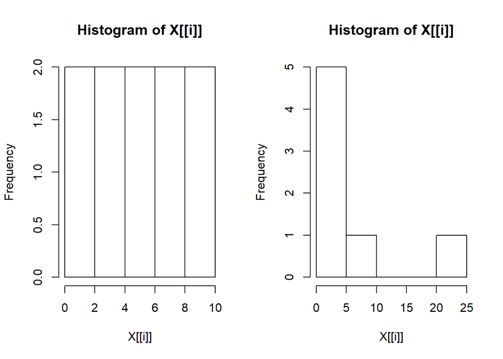

```
## $a
## $breaks
## [1]  0  2  4  6  8 10
##
## $counts
## [1] 2 2 2 2 2
##
## $density
## [1] 0.1 0.1 0.1 0.1 0.1
##
## $mids
## [1] 1 3 5 7 9
##
## $xname
## [1] "X[[i]]"
##
## $equidist
## [1] TRUE
##
## attr(,"class")
## [1] "histogram"
##
## $beta
## $breaks
## [1]  0  5 10 15 20 25
##
## $counts
## [1] 5 1 0 0 1
##
## $density
## [1] 0.14285714 0.02857143 0.00000000 0.00000000 0.02857143
##
## $mids
## [1]  2.5  7.5 12.5 17.5 22.5
##
## $xname
## [1] "X[[i]]"
##
## $equidist
## [1] TRUE
##
## attr(,"class")
## [1] "histogram"
```

```r
par(mfrow = c(1, 2))
lapply(C, hist)
```

## Function: sapply(…)

### Function: sapply(…)

**sapply(X, FUN, …, simplify = TRUE**

Similarlly to lapply(X, FUN, …) if sapply(x, f, simplify = FALSE, USE.NAMES = FALSE)

- X: vector or data frame or list
- FUN: name of a function
- simplify: logical; TRUE will return an array or a matrix with the same length of oytput

```r
sapply(C, summary)
```

```
##             a        beta
## Min.     1.00  0.04978707
## 1st Qu.  3.25  0.25160736
## Median   5.50  1.00000000
## Mean     5.50  4.53512523
## 3rd Qu.  7.75  5.05366896
## Max.    10.00 20.08553692
```

```r
sapply(C, summary, simplify = FALSE)
```

```
## $a
##    Min. 1st Qu.  Median    Mean 3rd Qu.    Max.
##    1.00    3.25    5.50    5.50    7.75   10.00
##
## $beta
##     Min.  1st Qu.   Median     Mean  3rd Qu.     Max.
##  0.04979  0.25161  1.00000  4.53512  5.05367 20.08554
```

```r
lapply(C, summary)
```

```
## $a
##    Min. 1st Qu.  Median    Mean 3rd Qu.    Max.
##    1.00    3.25    5.50    5.50    7.75   10.00
##
## $beta
##     Min.  1st Qu.   Median     Mean  3rd Qu.     Max.
##  0.04979  0.25161  1.00000  4.53512  5.05367 20.08554
```

### If there are different lengths in the result?

Using **apply**, it returns a list.

```r
D <- list(a = sample(1:10, 10 ,replace = TRUE), b = sample(1:5, 20 ,replace = TRUE))
sapply(D, unique)
```

```
## $a
## [1]  2  3  8  1 10  9  4
##
## $b
## [1] 3 2 4 1 5
```

```r
sapply(D, table)
```

```
## $a
##
##  1  2  3  4  8  9 10
##  1  3  2  1  1  1  1
##
## $b
##
## 1 2 3 4 5
## 4 4 3 7 2
```

## Others

tapply(…)